# Introduction

These are all the graphics used on the home (https://fergustaylor.github.io/Arran/) page.

N.B. The previews shown underneath their code often look cramped here. This is because the image elements shuffle themselves around depending on the available dimensions, rather than scaling at a set ratio. As such you can create much nicer images by running the same code through the console and exporting the image at custom (larger) dimensions.

# Dependencies

N.B. There are codeblocks here which have been hidden by default as they are just repeats of the start of ‘code’. This just the point where in a new environment you would need to load up the same packages as before, and import/create the data in ‘code’, to make the below graphics produceable in R. Anything new starts after ///.

If you’d like to see this code, it’s visible in the .rmd at ‘front_page_graphics.Rmd’.. Or directly from github https://github.com/fergustaylor/Arran (in /docs).

///

# Front-Page Graphics

First - create a small function to make the plots work.

```r
function0.5 <- function(argument)
{
  filter(arransimd, DataZone==argument)
}
```

The code for each plot is hidden by default, select ‘code’/‘hide’ on the right to individually show/hide the code used for each plot.

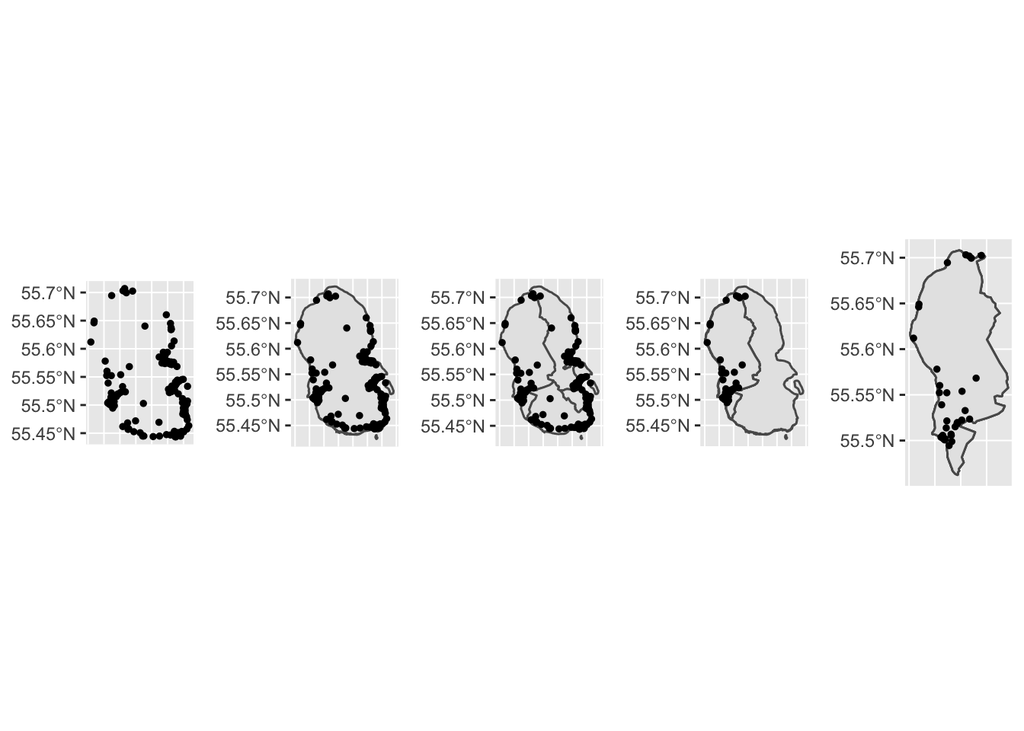

```r
plot1 <- ggplot() +
  theme_grey() +
  geom_point(data = arrancoordinates,
             mapping = aes(x = longitude, y = latitude), size=1) +
  theme(axis.title.x = element_blank(),
        axis.title.y = element_blank(),
        axis.text.x = element_blank(),
        axis.ticks.x = element_blank()) +
  coord_sf(crs= 4326, datum = sf::st_crs(4326))

plot2 <- ggplot() +
  geom_sf(data = arransubsect) +
  theme_grey() +
  geom_point(data = arrancoordinates,
             mapping = aes(x = longitude, y = latitude), size=1) +
  theme(axis.title.x = element_blank(),
        axis.title.y = element_blank(),
        axis.text.x = element_blank(),
        axis.ticks.x = element_blank()) +
  coord_sf(crs= 4326, datum = sf::st_crs(4326))

plot3 <- ggplot() +
  geom_sf(data = arran2016) +
  theme_grey() +
  geom_point(data = arrancoordinates,
             mapping = aes(x = longitude, y = latitude), size=1) +
  theme(axis.title.x = element_blank(),
        axis.title.y = element_blank(),
        axis.text.x = element_blank(),
        axis.ticks.x = element_blank()) +
  coord_sf(crs= 4326, datum = sf::st_crs(4326))

plot4 <- ggplot() +
  geom_sf(data = arransubsect) +
  geom_sf(data= function0.5("S01004372")) +
  geom_point(data = arrancoordinates[namingdzpostcode[[2]],],
             mapping = aes(x = longitude, y = latitude), size=1) +
  theme_grey() +
  theme(axis.title.x = element_blank(),
        axis.title.y = element_blank(),
        axis.text.x = element_blank(),
        axis.ticks.x = element_blank()) +
  coord_sf(crs= 4326, datum = sf::st_crs(4326))

plot5 <- function0.5("S01004372") %>%
  ggplot() +
  geom_sf() +
  theme_grey() +
  geom_point(data = arrancoordinates[namingdzpostcode[[2]],],
             mapping = aes(x = longitude, y = latitude), size=1) +
  theme(axis.title.x = element_blank(),
        axis.title.y = element_blank(),
        axis.text.x = element_blank(),
        axis.ticks.x = element_blank()) +
  coord_sf(crs= 4326, datum = sf::st_crs(4326))

grid.arrange(plot1, plot2, plot3, plot4, plot5, nrow = 1)
```

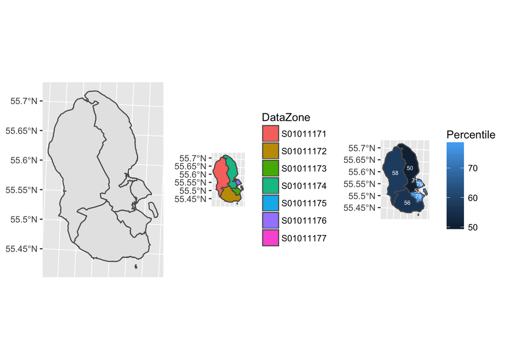

```r
plot6 <- arran2016 %>%
  ggplot() +
  geom_sf() +
  theme_grey() +
  theme(legend.position="none") +
  theme(axis.text.x=element_blank(),
        axis.ticks.x=element_blank())

plot7 <- arran2016 %>%
  ggplot() +
  geom_sf(aes(fill = DataZone)) +
  theme_grey() +
  theme(axis.text.x=element_blank(),
        axis.ticks.x=element_blank())

plot8 <- arran2016 %>%
mutate(
    lon = map_dbl(geometry, ~st_centroid(.x)[[1]]),
    lat = map_dbl(geometry, ~st_centroid(.x)[[2]])
    ) %>%
  ggplot() +
  geom_sf(aes(fill = Percentile)) +
  theme_grey() +
  geom_text(aes(label = Percentile, x = lon, y = lat), size = 2, colour = "white") +
  theme(axis.text.x=element_blank(),
        axis.ticks.x=element_blank(),
        axis.title.x = element_blank(),
        axis.title.y = element_blank())

grid.arrange(plot6, plot7, plot8, nrow = 1)
```

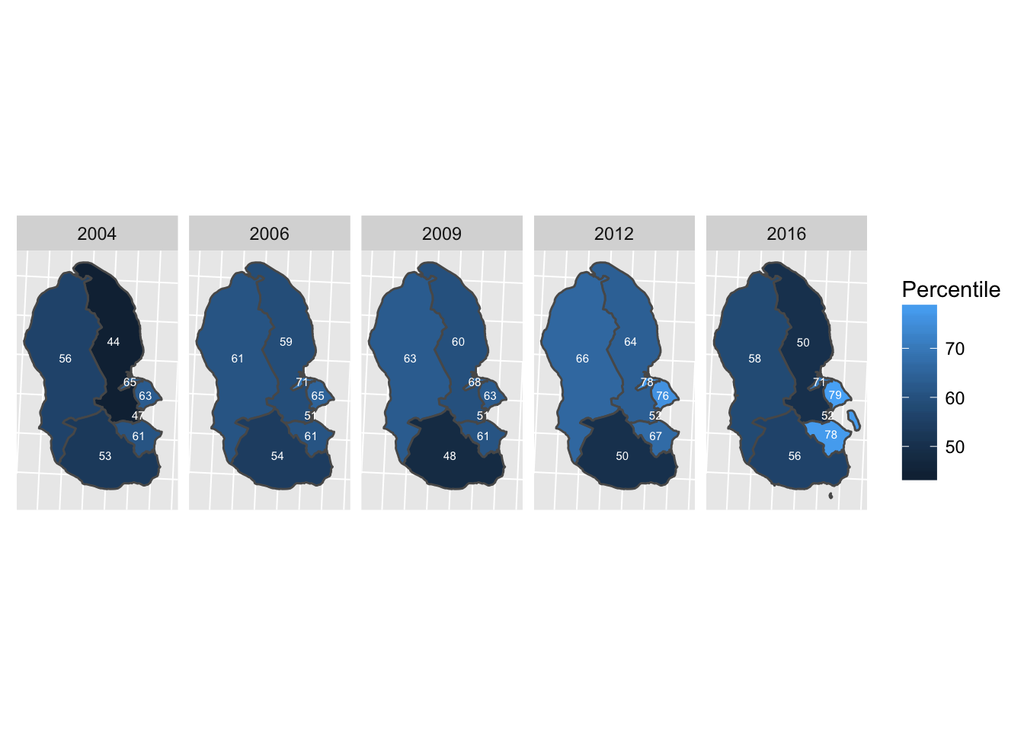

```r
arransimd %>%
ggplot() +
  geom_sf(aes(fill = Percentile)) +
  facet_wrap('year', nrow = 1) +
  theme_grey() +
  geom_text(aes(label = Percentile, x = lon, y = lat), size = 2, colour = "white") +
  theme(axis.text.x=element_blank(),
        axis.ticks.x=element_blank(),
        axis.title.x = element_blank(),
        axis.title.y = element_blank(),
        axis.text.y=element_blank(),
        axis.ticks.y=element_blank()) +
  theme(legend.position="right")
```

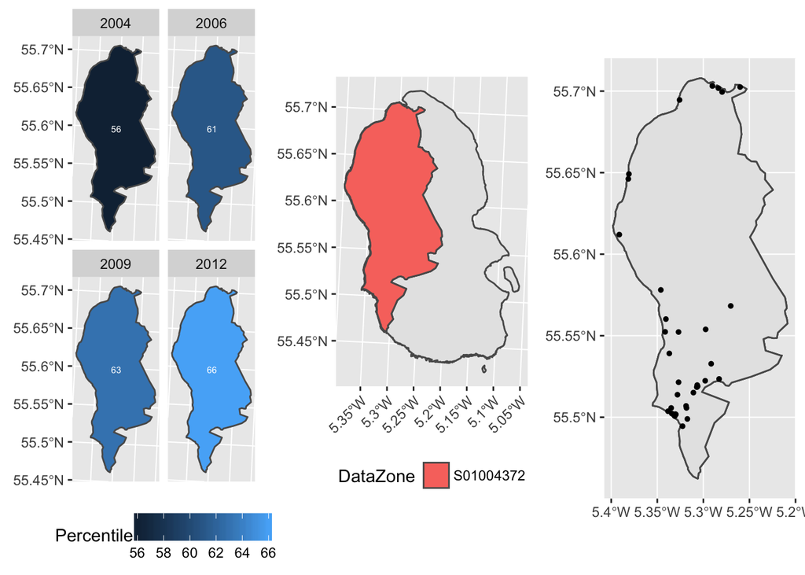

```r
function1.5.5 <- function(argument)
{
  argument %>%
mutate(
    lon = map_dbl(geometry, ~st_centroid(.x)[[1]]),
    lat = map_dbl(geometry, ~st_centroid(.x)[[2]])
    ) %>%
  ggplot() +
  geom_sf(aes(fill = Percentile)) +
  facet_wrap('year') +
  theme_grey() +
  geom_text(aes(label = Percentile, x = lon, y = lat), size = 2, colour = "white") +
  theme(axis.text.x=element_blank(),
        axis.ticks.x=element_blank(),
        axis.title.x = element_blank(),
        axis.title.y = element_blank()) +
  theme(legend.position="bottom")
}

function2.5.1 <- function(argument)
{
  arransubsect %>%
  ggplot() +
  geom_sf() +
  theme_grey() +
  theme(axis.text.x=element_text(angle=45, hjust = 1)) +
  theme(legend.position="bottom") +
  geom_sf(data= argument, aes(fill = DataZone))
}

function5 <- function(argument, argument2)
{
  argument %>%
  ggplot() +
  geom_sf() +
  theme_grey() +
  geom_point(data=function6(argument2), mapping = aes(x = longitude, y = latitude), size=1) +
  theme(axis.title.x = element_blank(),
        axis.title.y = element_blank()) +
  coord_sf(crs= 4326, datum = sf::st_crs(4326))
}

function6 <- function(argument)
{
  arrancoordinates[namingdzpostcode[[argument]],]
}

function7.5.1 <- function(argument, argument2)
{
  a <- function1.5.5(argument)
  b <- function2.5.1(argument)
  c <- function5(argument, argument2)
  grid.arrange(a, b, c, nrow = 1)
}

function7.5.1(function0.5("S01004372"),2)
```

See the rest of these plots.